# Clustering and Classification on Irıs Dataset

## K-means Clustering on Iris Dataset

K-means clustering is a popular unsupervised learning algorithm used in data mining and machine learning. The aim of the k-means algorithm is to partition a set of observations into k clusters (where k is a pre-defined number) based on their similarities.

The algorithm starts by randomly selecting k centroids, where each centroid represents the center of a cluster. Then, each observation is assigned to the nearest centroid based on the Euclidean distance between the observation and the centroid. After all observations are assigned, the centroids are recalculated based on the mean values of the observations in each cluster. This process of assigning observations to the nearest centroid and recalculating the centroids continues until convergence is achieved (i.e., the centroids no longer move).

The k-means algorithm can be applied to a wide variety of datasets and is particularly useful in cases where the data has a clear structure or can be easily partitioned into distinct groups. The approach is commonly used for tasks such as image segmentation, customer segmentation, and anomaly detection, among others.

Overall, the goal of the k-means clustering algorithm is to identify groups of observations that are similar to each other, while being different from observations in other groups. This can help in gaining insights into the underlying structure of the data and making data-driven decisions.

## Load Required Libraries

Load the necessary libraries: ggplot2: for data visualization. dplyr: for data manipulation. cluster: for implementing the k-means clustering algorithm. class and rpart: for classification techniques

## Descriptive Statistics on the Dataset

```r
# Load the Iris dataset
iris_data <- read.csv("iris.csv", header = TRUE)

# Display the first few rows of the dataset
cat("Dataset Overview:\n")
```

```
## Dataset Overview:
```

```r
head(iris_data)
```

```
##   sepal.length sepal.width petal.length petal.width variety
## 1          5.1         3.5          1.4         0.2  Setosa
## 2          4.9         3.0          1.4         0.2  Setosa
## 3          4.7         3.2          1.3         0.2  Setosa
## 4          4.6         3.1          1.5         0.2  Setosa
## 5          5.0         3.6          1.4         0.2  Setosa
## 6          5.4         3.9          1.7         0.4  Setosa
```

```r
# Perform descriptive statistics on the dataset
cat("\nDescriptive Statistics:\n")
```

```
##
## Descriptive Statistics:
```

```r
summary(iris_data)
```

```
##   sepal.length    sepal.width     petal.length    petal.width
##  Min.   :4.300   Min.   :2.000   Min.   :1.000   Min.   :0.100
##  1st Qu.:5.100   1st Qu.:2.800   1st Qu.:1.600   1st Qu.:0.300
##  Median :5.800   Median :3.000   Median :4.350   Median :1.300
##  Mean   :5.843   Mean   :3.057   Mean   :3.758   Mean   :1.199
##  3rd Qu.:6.400   3rd Qu.:3.300   3rd Qu.:5.100   3rd Qu.:1.800
##  Max.   :7.900   Max.   :4.400   Max.   :6.900   Max.   :2.500
##    variety
##  Length:150
##  Class :character
##  Mode  :character
##
##
##
```

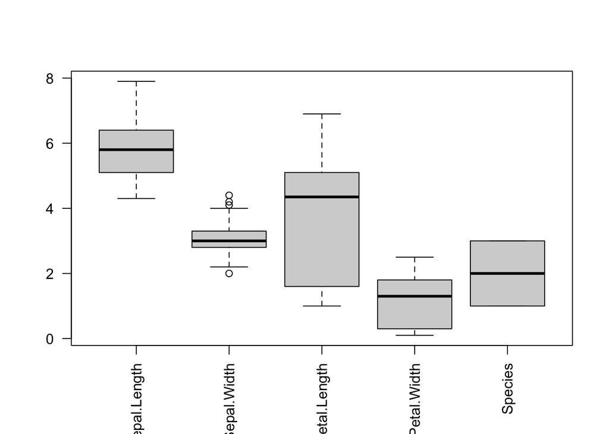

```r
boxplot(iris, las=2)
```

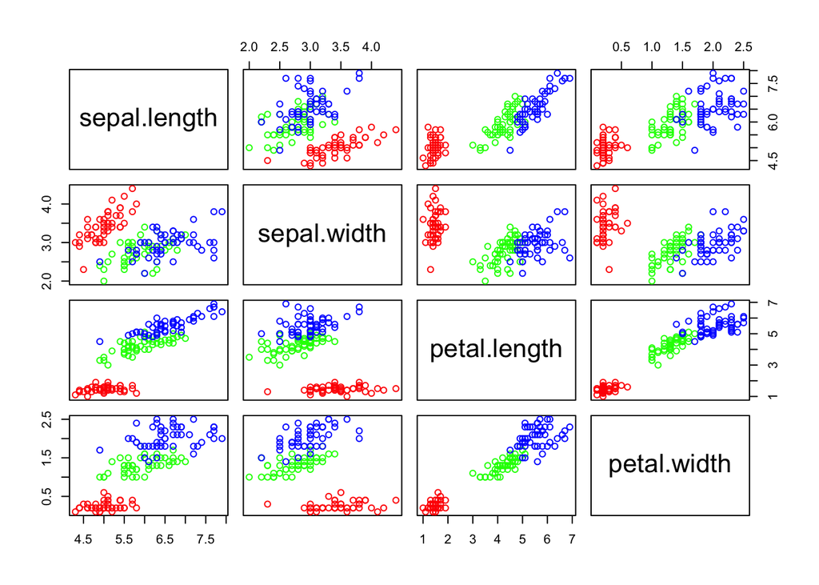

```r
speciesID <- as.numeric(iris$Species)
ma <- as.matrix(iris_data[, 1:4]) # convert to matrix
pairs(ma, col = rainbow(3)[speciesID]) # set colors by species
```

Extract the feature columns (sepal length, sepal width, petal length, petal width) from the dataset using indexing.

```r
# Extract the feature columns (sepal length, sepal width, petal length, petal width)
features <- iris_data[,1:4]
```

## K-means Clustering

Perform k-means clustering on the feature columns using kmeans() function from cluster library. Here, centers = 3 specifies the number of clusters. Set the random seed for reproducibility using set.seed() function. Fit the k-means model to the features using the kmeans() function. Add the predicted cluster labels to the dataset by creating a new column called ‘Cluster’ using $ operator.

```r
# Perform k-means clustering on the dataset
set.seed(42)  # For reproducibility
kmeans_model <- kmeans(features, centers = 3)

# Add the predicted cluster labels to the dataset
iris_data$Cluster <- kmeans_model$cluster
```

Visualize the clusters using ggplot() function from ggplot2 library. This plots the ‘sepal.length’ on the x-axis and ‘petal.length’ on the y-axis, with different colors representing different clusters. Add labels to the x-axis, y-axis, and the title of the plot using xlab(), ylab(), and ggtitle() functions, respectively.

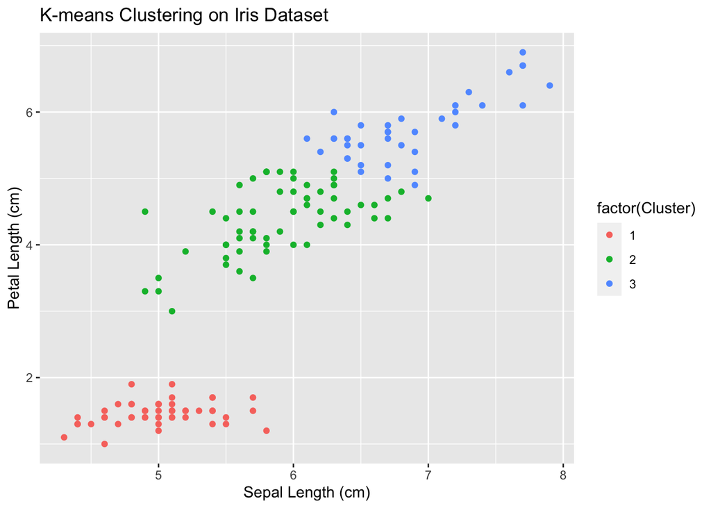

```r
# Visualize the clusters
ggplot(iris_data, aes(x = sepal.length, y = petal.length, color = factor(Cluster))) +
  geom_point() +
  xlab("Sepal Length (cm)") +
  ylab("Petal Length (cm)") +
  ggtitle("K-means Clustering on Iris Dataset")
```

# K-means Clustering with Different Number of Clusters

In this section, ignoring the information we have three distinct labels in the dataset, different number of clusters can be tried in k-means clustering and their performances can be compared.

```r
# Set the range of number of clusters to try
num_clusters <- 2:5
```

```r
# Create a list to store the k-means models and their accuracy scores
models <- list()
accuracy_scores <- list()

# Perform k-means clustering on the dataset with different number of clusters
for (i in num_clusters) {
  # Set the random seed for reproducibility
  set.seed(42)
  # Fit the k-means model to the features
  kmeans_model <- kmeans(features, centers = i)
  # Add the predicted cluster labels to the dataset
  iris_data[paste0("Cluster_", i)] <- kmeans_model$cluster
  # Store the model and accuracy score in their respective lists
  models[[i-1]] <- kmeans_model
  accuracy_scores[[i-1]] <- kmeans_model$betweenss/kmeans_model$totss
}
```

```r
# Print the accuracy scores for each number of clusters
cat("\nAccuracy Scores for Different Number of Clusters:\n")
```

```
##
## Accuracy Scores for Different Number of Clusters:
```

```r
for (i in num_clusters) {
  cat(paste0("Number of Clusters = ", i, ", Accuracy Score = ", round(accuracy_scores[[i-1]], 3), "\n"))
}
```

```
## Number of Clusters = 2, Accuracy Score = 0.776
## Number of Clusters = 3, Accuracy Score = 0.884
## Number of Clusters = 4, Accuracy Score = 0.916
## Number of Clusters = 5, Accuracy Score = 0.927
```

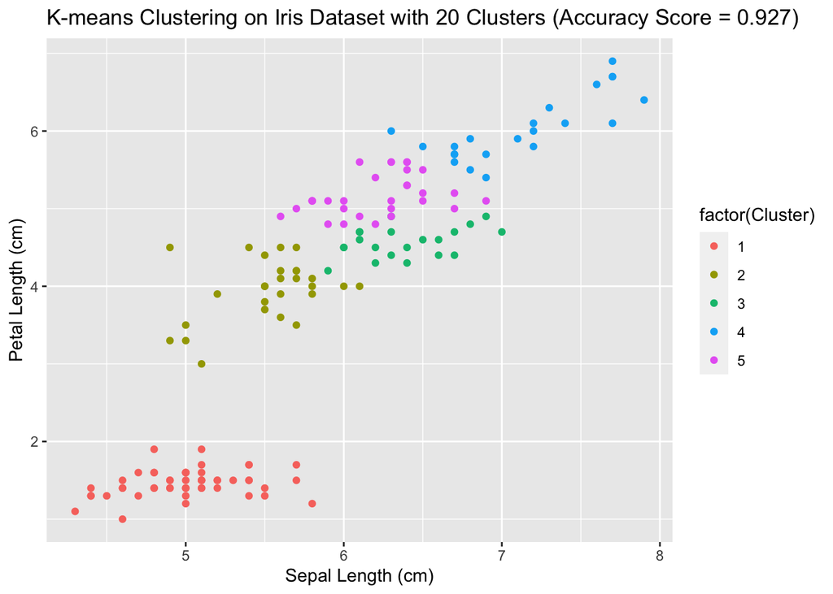

```r
# Visualize the clusters for the best k-means model (highest accuracy score)
best_model <- models[[which.max(accuracy_scores)]]
iris_data$Cluster <- best_model$cluster
ggplot(iris_data, aes(x = sepal.length, y = petal.length, color = factor(Cluster))) +
  geom_point() +
  xlab("Sepal Length (cm)") +
  ylab("Petal Length (cm)") +
  ggtitle(paste0("K-means Clustering on Iris Dataset with ", length(best_model$centers), " Clusters (Accuracy Score = ", round(accuracy_scores[[which.max(accuracy_scores)]], 3), ")"))
```

## Classification

### Training and Validation Sets

```r
# Split the dataset into training and validation sets
set.seed(123)
train.index <- sample(1:nrow(iris_data), round(2/3 * nrow(iris_data)), replace = FALSE)
train.data <- iris_data[train.index, ]
valid.data <- iris_data[-train.index, ]

# Define the target variable
target <- "variety"
```

### K-nearest Models

A k-nearest-neighbor algorithm, often abbreviated k-nn, is an approach to data classification that estimates how likely a data point is to be a member of one group or the other depending on what group the data points nearest to it are in.

```r
# K-nearest neighbor algorithm
knn.model <- knn(train = train.data[, -which(names(train.data) == target)],
                 test = valid.data[, -which(names(valid.data) == target)],
                 cl = train.data[, target], k = 3)
knn.accuracy <- sum(knn.model == valid.data[, target]) / nrow(valid.data)
```

### Decision Tree Model

Decision Tree algorithm belongs to the family of supervised learning algorithms. Unlike other supervised learning algorithms, the decision tree algorithm can be used for solving regression and classification problems too.

```r
# Decision tree algorithm
dt.model <- rpart(variety ~ ., data = train.data, method = "class")
dt.predictions <- predict(dt.model, newdata = valid.data, type = "class")
dt.accuracy <- sum(dt.predictions == valid.data[, target]) / nrow(valid.data)
```

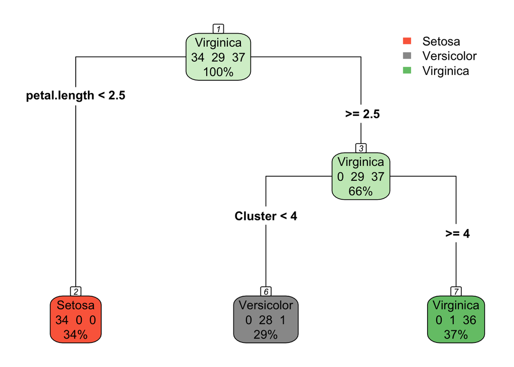

```r
# Load the rpart.plot library for visualizing decision trees
library(rpart.plot)

# Plot the decision tree model
rpart.plot(dt.model, type = 4, extra = 101, box.palette = "auto", nn = TRUE)
```

```r
# Compare the accuracies of the models
accs <- c(knn = knn.accuracy, dt = dt.accuracy)
accs
```

```
##  knn   dt
## 0.96 0.96
```